# Visual Drivers of Mortgage Default Risk: Evidence from Fannie Mae Loan Data

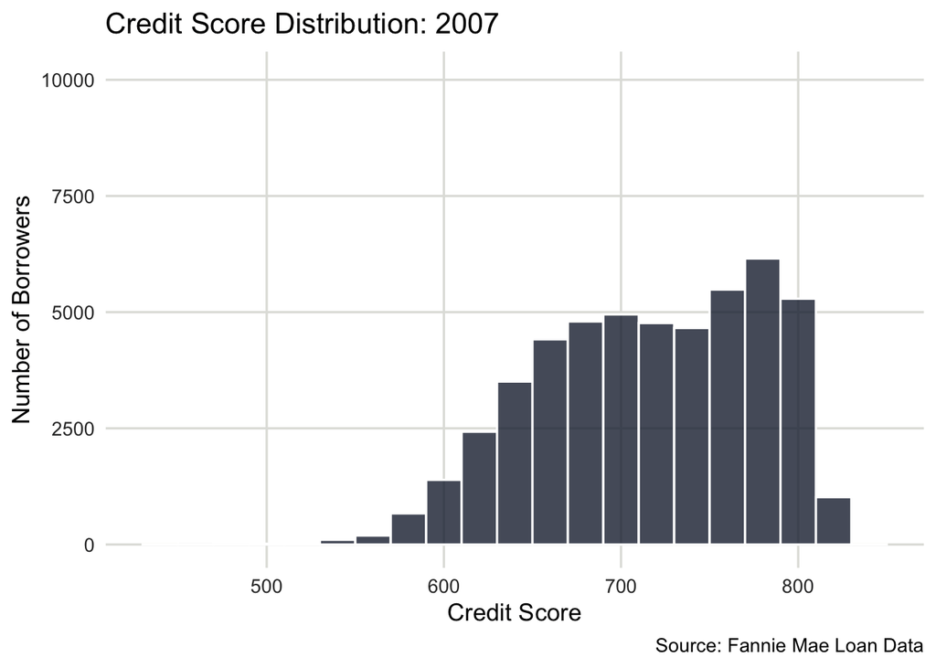

**Loans with higher interest rates are more likely to default:**

The boxplot for the original interest rates for the defaulted loans and the non-defaulted loans shows that the **original interest rates for the defaulted loans tend to be higher**. The interest rate, therefore, acts as an indicator for the perceived risk for the lender. Median interest rates for defaulted loans are obviously higher than non-defaulted loans. Defaulted loans **exhibit a higher interquartile range**, implying higher variability in the pricing of risks.The gap between the two distributions validates the fact that interest rate is a forward-looking risk indicator.

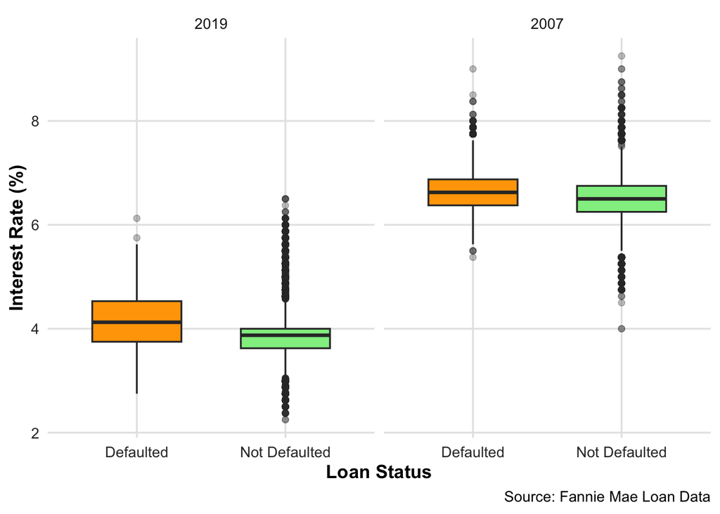

**Occupancy status of the borrower:**

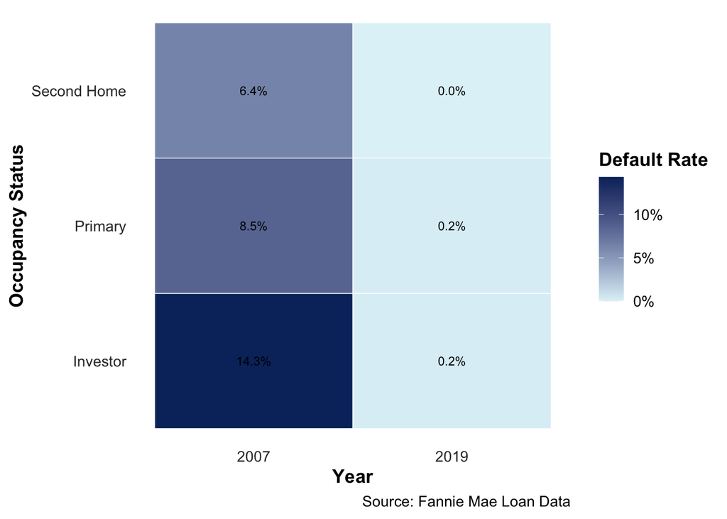

**Conclusion:**

The analysis has clearly demonstrated that borrower credit quality, leverage of borrowers, and occupancy status are significant indicators of default rates. In addition, loans made during 2007 experience higher default rates and are riskier than loans made during 2019. This shows that lenders became more cautious during the financial crisis and are providing a safer and more resilient portfolio of loans.

From a risk management perspective, lenders should closely monitor loans made to borrowers with higher leverage and lower credit scores. Although default rates are stable at the moment, default risk is still a significant issue for lenders and is concentrated within specific borrower groups.

In all, this analysis sheds valuable light on default trends for borrowers by making correlations between loans and risk outcomes, allowing lenders to make informed decisions.